# Entrega 2 del Trabajo de Estadística para el Análisis Político II

Jhoselyn Enith Martinez Urday e Irinnia Del Carmen Vargas Velasquez

31/10/2021

| - **Tema de investigación**: |
| --- |
| Factores que explican la violencia física y psicológica contra los niños y niñas en ell contexto familiar y escolar en el Perú |
| - **Pregunta de investigación**: |
| ¿Cuáles son los factores que permiten explicar la violencia física y psicológica ejercida contra los niños y niñas de 9 a 11 años en el Perú? |
| - **Objetivos del trabajo**: |
| **Objetivo General**: Determinar los factores que explican la violencia física y psicológica ejercida contra los niños y niñas de 9 a 11 años en el Perú |
| **Objetivos específicos**: |
| 1. Establecer los factores específicos que permiten explicar tanto la violencia física como psicológica ejercida en los hogares contra los niños y niñas de 9 a 11 años en el Perú 2. Establecer los fac… |
| - **Hipótesis**: |
| 1. El lugar de residencia, la constitución de la familia, la edad, la condición socioeconómica y el género son los factores más relevantes que permiten explicar un alto nivel de violencia física ejerc… |
| - **Problema Público**: |
| Alto índice de violencia física y psicológica ejercida contra niños y niñas de 9 a 11 años en el Perú durante el año 2019 |
| - **Contextualización del problema público**: |
| Según el Observatorio Nacional de la Violencia contra las mujeres y los integrantes del grupo familiar, el “73.8% de niños y niñas de 9 a 11 años de edad, alguna vez en su vida fueron víctimas de viol… |
| ###### **Políticas públicas, marco regulatorio y acción del Estado** |
| Como parte de un marco regulatorio establecido por el Estado peruano para velar por la integridad y bienestar de los niños, niñas y adolescentes se pueden identificar las siguientes leyes y decretos: |
| - La Ley del Sistema Nacional de Atención Integral al Niño y el Adolescente (Ley N° 26518) que tiene como fin orientar, integrar, estructurar, coordinar, monitorear y evaluar las políticas, planes y p… |
| Ahora bien, en cuanto a políticas públicas se destaca la formulación del Plan Nacional de Acción por la Infancia y la Adolescencia (PNAIA) que se enmarca en el periodo 2012-2021 teniendo como ejes la … |
| ###### **Factores asociados al problema de interés** |
| Tras una revisión de la literatura, se ha encontrado que el abordaje de la violencia física y psicológica en niños, niñas y adolescentes es de carácter multicausal, lo que implica un análisis en los d… |

> **Explorar base de datos**

```r
str(C100)
```

[output not shown]

[output cut: 483 more lines]

```
##  $ C3P128         : num  1 1 1 1 1 1 1 1 1 1 ...
##   ..- attr(*, "label")= chr "128. HABITUALMENTE ¿QUÉ  IDIOMA O LENGUA HABLAN LAS PERSONAS QUE VIVEN EN TU CASA?"
##   ..- attr(*, "format.spss")= chr "F11.0"
##   ..- attr(*, "display_width")= int 0
##   ..- attr(*, "labels")= Named num [1:6] 1 2 3 4 5 6
##   .. ..- attr(*, "names")= chr [1:6] "Castellano?" "Quechua?" "Aymara?" "Otra lengua nativa?" ...
##  $ RESULTFINENTREV: num  1 1 1 1 1 1 1 1 1 1 ...
##   ..- attr(*, "label")= chr "RESULTADO FINAL DE LA ENTREVISTA"
##   ..- attr(*, "format.spss")= chr "F11.0"
##   ..- attr(*, "display_width")= int 0
##   ..- attr(*, "labels")= Named num [1:4] 1 2 3 4
##   .. ..- attr(*, "names")= chr [1:4] "Completa" "Incompleta" "Informante ausente" "Rechazo"
##  $ FACTOR_ALUMNOS : num  1209 1209 1209 1209 1209 ...
##   ..- attr(*, "format.spss")= chr "F16.13"
##   ..- attr(*, "display_width")= int 0
```

```r
str(C200)
```

[output not shown]

[output cut: 499 more lines]

```
##   ..- attr(*, "labels")= Named num 1
##   .. ..- attr(*, "names")= chr "Director/a del albergue"
##  $ C3P210_13      : num  0 0 0 0 0 NA 0 0 0 NA ...
##   ..- attr(*, "label")= chr "210.13 ¿A QUIÉN ACUDISTE PARA SOLICITARLE AYUDA? TUTOR/A)/CUIDADOR(A) DEL ALBERGUE"
##   ..- attr(*, "format.spss")= chr "F11.0"
##   ..- attr(*, "display_width")= int 0
##   ..- attr(*, "labels")= Named num 1
##   .. ..- attr(*, "names")= chr "Tutor/a Cuidador/a del albergue"
##  $ C3P210_14      : num  0 0 0 0 0 NA 0 0 0 NA ...
##   ..- attr(*, "label")= chr "210.14 ¿A QUIÉN ACUDISTE PARA SOLICITARLE AYUDA? COMPAÑERO/A DEL ALBERGUE"
##   ..- attr(*, "format.spss")= chr "F11.0"
##   ..- attr(*, "display_width")= int 0
##   ..- attr(*, "labels")= Named num 1
##   .. ..- attr(*, "names")= chr "Compañero/a del albergue"
##   [list output truncated]
```

```r
names(C100)
```

```
##  [1] "USUARIO_ID"      "CCDD"            "CCPP"            "CCDI"
##  [5] "CODCCPP"         "AREA"            "DIREED"          "UNGEEDLO"
##  [9] "COD_MOD"         "TIEDBA"          "NIED"            "INED"
## [13] "TURNO_M"         "TURNO_T"         "TURNO_N"         "RFINAL"
## [17] "COLEGIAL_ID"     "C3ANIO"          "TURNO"           "C3SECC"
## [21] "TOTAL_V"         "TOTAL_M"         "EDAD"            "SEXO"
## [25] "C3P102_MES"      "C3P102_ANIO"     "C3P103EDAD"      "C3P104"
## [29] "C3P105"          "C3P106"          "C3P110"          "C3P114_PERS"
## [33] "C3P114_VS"       "C3P115_1"        "C3P115_2"        "C3P115_3"
## [37] "C3P115_4"        "C3P115_5"        "C3P115_6"        "C3P115_7"
## [41] "C3P115_8"        "C3P115_9"        "C3P115_10"       "C3P115_11"
## [45] "C3P115_12"       "C3P115_13"       "C3P115_14"       "C3P116_HER"
## [49] "C3P116_NOH"      "C3P118_1"        "C3P118_2"        "C3P118_3"
## [53] "C3P118_4"        "C3P118_5"        "C3P118_6"        "C3P118_7"
## [57] "C3P118_8"        "C3P118_9"        "C3P118_10"       "C3P118_11"
## [61] "C3P118_12"       "C3P119_1"        "C3P119_2"        "C3P119_3"
## [65] "C3P119_4"        "C3P119_5"        "C3P119_6"        "C3P119_7"
## [69] "C3P119_8"        "C3P119_9"        "C3P119_10"       "C3P119_11"
## [73] "C3P119_12"       "C3P120"          "C3P120A"         "C3P120B"
## [77] "C3P120C"         "C3P120D"         "C3P120E"         "C3P120F"
## [81] "C3P120G"         "C3P120H_1"       "C3P120H_2"       "C3P120H_3"
## [85] "C3P120H_4"       "C3P120H_5"       "C3P120H_6"       "C3P120H_7"
## [89] "C3P121"          "C3P122"          "C3P123"          "C3P124"
## [93] "C3P125"          "C3P126"          "C3P127"          "C3P128"
## [97] "RESULTFINENTREV" "FACTOR_ALUMNOS"
```

```r
names(C200)
```

```
##   [1] "USUARIO_ID"      "CCDD"            "CCPP"            "CCDI"
##   [5] "CODCCPP"         "AREA"            "DIREED"          "UNGEEDLO"
##   [9] "COD_MOD"         "TIEDBA"          "NIED"            "INED"
##  [13] "TURNO_M"         "TURNO_T"         "TURNO_N"         "RFINAL"
##  [17] "COLEGIAL_ID"     "C3ANIO"          "TURNO"           "C3SECC"
##  [21] "TOTAL_V"         "TOTAL_M"         "EDAD"            "SEXO"
##  [25] "C3P201_1"        "C3P201A_1"       "C3P201B_1"       "C3P201_2"
##  [29] "C3P201A_2"       "C3P201B_2"       "C3P201_3"        "C3P201A_3"
##  [33] "C3P201B_3"       "C3P201_4"        "C3P201A_4"       "C3P201B_4"
##  [37] "C3P201_5"        "C3P201A_5"       "C3P201B_5"       "C3P201_6"
##  [41] "C3P201A_6"       "C3P201B_6"       "C3P201_7"        "C3P201A_7"
##  [45] "C3P201B_7"       "C3P201_8"        "C3P201A_8"       "C3P201B_8"
##  [49] "C3P201_9"        "C3P201A_9"       "C3P201B_9"       "C3P201_10"
##  [53] "C3P201A_10"      "C3P201B_10"      "C3P201_11"       "C3P201A_11"
##  [57] "C3P201B_11"      "C3P202"          "C3P203"          "C3P204"
```

[output cut: 87 more lines]

##### **Seleccionar variables de las bases de datos**

```r
C100 = C100 %>% select(-CCDD, -CCPP, -USUARIO_ID, -CODCCPP, -CCDI, -AREA, -COD_MOD, -TIEDBA, -RFINAL, -COLEGIAL_ID, -TURNO_N, -C3SECC, -C3P103EDAD, -C3P104, -C3P102_MES, -C3P102_ANIO, -C3P119_1, -C3P119_2, -C3P119_3, -C3P119_4, -C3P119_5, -C3P119_6, -C3P119_7, -C3P119_8, -C3P119_9, -C3P119_10, -C3P119_11, -C3P119_12, -C3P118_1, -C3P118_2, -C3P118_3, -C3P118_4, -C3P118_5, -C3P118_6, -C3P118_7, -C3P118_8, -C3P118_9, -C3P118_10, -C3P118_11, -C3P118_12, -C3P120F, -C3P120G, -C3P120H_1, -C3P120H_2, -C3P120H_3, -C3P120H_4, -C3P120H_5, -C3P120H_6, -C3P120H_7, -RESULTFINENTREV, -FACTOR_ALUMNOS)
```

```r
C200 = C200 %>% select(-CCDD, -CCPP, -USUARIO_ID, -CODCCPP, -CCDI, -AREA, -COD_MOD, -TIEDBA, -RFINAL, -COLEGIAL_ID, -TURNO_N, -C3SECC, -C3P201_11, -C3P201A_11, -C3P201B_11, -C3P205_7, -C3P205A_7, -C3P205B_7, -C3P216A_3, -C3P216A_3C, -C3P216A_5, -C3P216A_5C, -C3P216A_6, -C3P216A_6C, -C3P216C_1, -C3P216C_1C, -C3P216C_2, -C3P216C_2C, -C3P216C_3, -C3P216C_3C, -C3P216C_4, -C3P216C_4C, -C3P216C_5, -C3P216C_5C, -C3P221, -C3P223_14, -C3P223A_14, -C3P223B_14, -C3P223C_14, -C3P223D_14, - C3P227_10, -C3P227A_10, -C3P227B_10, -C3P227C_10, -C3P227D_10, -RESULTFINENTREV, -FACTOR_ALUMNOS)
```

##### **Combinar bases de datos**

```r
enares_2019 = C100 %>% left_join(C200)
### Explorar base de datos a usar en el reporte
str(enares_2019)
```

[output not shown]

[output cut: 515 more lines]

```
##   ..- attr(*, "format.spss")= chr "F11.0"
##   ..- attr(*, "display_width")= int 0
##   ..- attr(*, "labels")= Named num [1:22] 1 2 3 4 5 6 7 8 9 10 ...
##   .. ..- attr(*, "names")= chr [1:22] "Madre" "Padre" "Madrastra" "Padrastro" ...
##  $ C3P205B_6  : num  NA NA NA NA NA NA NA NA NA NA ...
##   ..- attr(*, "label")= chr "205.6 ¿ESTA PERSONA VIVE CONTIGO?"
##   ..- attr(*, "format.spss")= chr "F11.0"
##   ..- attr(*, "display_width")= int 0
##   ..- attr(*, "labels")= Named num [1:2] 1 2
##   .. ..- attr(*, "names")= chr [1:2] "Si" "No"
##  $ C3P206     : num  6 8 8 9 6 8 7 NA 5 NA ...
##   ..- attr(*, "label")= chr "206. ¿QUÉ EDAD TENÍAS CUANDO TE OCURRIERON ESTAS SITUACIONES POR PRIMERA VEZ?"
##   ..- attr(*, "format.spss")= chr "F11.0"
##   ..- attr(*, "display_width")= int 0
##   [list output truncated]
```

> **Configuración de variables**
- **Variable: Sexo**

```
##  num [1:3426] 1 1 1 1 1 1 2 2 2 2 ...
##  - attr(*, "label")= chr "101. SEXO"
##  - attr(*, "format.spss")= chr "F11.0"
##  - attr(*, "display_width")= int 0
##  - attr(*, "labels")= Named num [1:2] 1 2
##   ..- attr(*, "names")= chr [1:2] "Mujer" "Hombre"
```

```
## [1] "character"
```

```
##
## Hombre  Mujer
##   1644   1782
```

- **Variable: Turno_Mañana**

```
##  num [1:3426] 1 1 1 1 1 1 1 1 1 1 ...
##  - attr(*, "label")= chr "TURNO_IE MAÑANA"
##  - attr(*, "format.spss")= chr "F11.0"
##  - attr(*, "display_width")= int 0
##  - attr(*, "labels")= Named num 1
##   ..- attr(*, "names")= chr "Mañana"
```

```
##
##    0    1
##   30 3396
```

```
##
##    No_Mañana Turno_Mañana
##           30         3396
```

- **Variable: Turno_Tarde**

```
##  num [1:3426] 0 0 0 0 0 0 0 0 0 0 ...
##  - attr(*, "label")= chr "TURNO_IE TARDE"
##  - attr(*, "format.spss")= chr "F11.0"
##  - attr(*, "display_width")= int 0
##  - attr(*, "labels")= Named num 1
##   ..- attr(*, "names")= chr "Tarde"
```

```
##
##    0    1
## 2402 1024
```

```
##
##    No_Tarde Turno_Tarde
##        2402        1024
```

- **Variable: Total de varones y mujeres**

```r
str(enares_2019$TOTAL_V)
```

```
##  num [1:3426] 3 3 3 3 3 3 3 3 3 3 ...
##  - attr(*, "label")= chr "TOTAL DE VARONES DE LA SECCIÓN"
##  - attr(*, "format.spss")= chr "F11.0"
##  - attr(*, "display_width")= int 0
```

```r
str(enares_2019$TOTAL_M)
```

```
##  num [1:3426] 3 3 7 7 3 3 7 3 3 7 ...
##  - attr(*, "label")= chr "TOTAL DE MUJERES  DE LA SECCIÓN"
##  - attr(*, "format.spss")= chr "F11.0"
##  - attr(*, "display_width")= int 0
```

- **Variable: Tipo de vivienda**

```
##  num [1:3426] 1 1 1 1 1 1 1 1 1 1 ...
##  - attr(*, "label")= chr "105. ¿EL LUGAR DONDE VIVES ES UNA CASA O UN ALBERGUE (Centro de acogida residencial)?"
##  - attr(*, "format.spss")= chr "F11.0"
##  - attr(*, "display_width")= int 0
##  - attr(*, "labels")= Named num [1:2] 1 2
##   ..- attr(*, "names")= chr [1:2] "Casa" "Albergue"
```

```
##
##    1    2
## 3424    2
```

```
##
## Albergue     Casa
##        2     3424
```

```r
### Variable: Niño y/o niña considera que la agresión se debe al hecho de tener plata
str(enares_2019$C3P232_3)
```

```
##  num [1:3426] 0 0 0 0 0 0 0 0 0 0 ...
##  - attr(*, "label")= chr "232.3 ¿POR QUÉ CREES QUE TUS COMPAÑERAS O COMPAÑEROS DE SALÓN O LAS ALUMNAS O ALUMNOS DEL COLEGIO TE TRATAN ASÍ"| __truncated__
##  - attr(*, "format.spss")= chr "F11.0"
##  - attr(*, "display_width")= int 0
##  - attr(*, "labels")= Named num 1
##   ..- attr(*, "names")= chr "Por tener plata"
```

```r
table(enares_2019$C3P232_3)
```

```
##
##    0    1
## 2248   10
```

```r
enares_2019$C3P232_3<- car::recode(enares_2019$C3P232_3, "1='Tiene Plata'; 0='No Plata'")
enares_2019=enares_2019%>%rename(Tiene_Plata=C3P232_3)
table(enares_2019$Tiene_Plata)
```

```
##
##    No Plata Tiene Plata
##        2248          10
```

```r
#### Variable: Niño y/o niña considera que la agresión se debe al hecho de no tener plata
str(enares_2019$C3P232_4)
```

```
##  num [1:3426] 0 0 0 0 0 0 0 0 0 0 ...
##  - attr(*, "label")= chr "232.4 ¿POR QUÉ CREES QUE TUS COMPAÑERAS O COMPAÑEROS DE SALÓN O LAS ALUMNAS O ALUMNOS DEL COLEGIO TE TRATAN ASÍ"| __truncated__
##  - attr(*, "format.spss")= chr "F11.0"
##  - attr(*, "display_width")= int 0
##  - attr(*, "labels")= Named num 1
##   ..- attr(*, "names")= chr "Por no tener plata"
```

```r
table(enares_2019$C3P232_4)
```

```
##
##    0    1
## 2240   18
```

```r
enares_2019$C3P232_4<- car::recode(enares_2019$C3P232_4, "1='No Plata'; 0='Tiene plata'")
enares_2019=enares_2019%>%rename(No_Tiene_Plata=C3P232_4)
table(enares_2019$No_Tiene_Plata)
```

```
##
##    No Plata Tiene plata
##          18        2240
```

```r
### Variable: Niño y/o niña considera que la agresión se debe al hecho de sacar buenas notas
str(enares_2019$C3P232_6)
```

```
##  num [1:3426] 0 0 0 0 0 0 0 0 1 0 ...
##  - attr(*, "label")= chr "232.6 ¿POR QUÉ CREES QUE TUS COMPAÑERAS O COMPAÑEROS DE SALÓN O LAS ALUMNAS O ALUMNOS DEL COLEGIO TE TRATAN ASÍ"| __truncated__
##  - attr(*, "format.spss")= chr "F11.0"
##  - attr(*, "display_width")= int 0
##  - attr(*, "labels")= Named num 1
##   ..- attr(*, "names")= chr "Por sacar buenas notas"
```

```r
table(enares_2019$C3P232_6)
```

```
##
##    0    1
## 2127  131
```

```r
enares_2019$C3P232_6<- car::recode(enares_2019$C3P232_6, "1='Buenas Notas'; 0='No Buenas Notas'")
enares_2019=enares_2019%>%rename(Buenas_Notas=C3P232_6)
table(enares_2019$Buenas_Notas)
```

```
##
##    Buenas Notas No Buenas Notas
##             131            2127
```

```r
### Variable: Niño y/o niña considera que la agresión se debe al hecho de sacar malas notas
str(enares_2019$C3P232_7)
```

```
##  num [1:3426] 0 0 0 0 0 0 0 0 0 0 ...
##  - attr(*, "label")= chr "232.7 ¿POR QUÉ CREES QUE TUS COMPAÑERAS O COMPAÑEROS DE SALÓN O LAS ALUMNAS O ALUMNOS DEL COLEGIO TE TRATAN ASÍ"| __truncated__
##  - attr(*, "format.spss")= chr "F11.0"
##  - attr(*, "display_width")= int 0
##  - attr(*, "labels")= Named num 1
##   ..- attr(*, "names")= chr "Por tener malas notas"
```

```r
table(enares_2019$C3P232_7)
```

```
##
##    0    1
## 2223   35
```

```r
enares_2019$C3P232_7<- car::recode(enares_2019$C3P232_7, "1='Malas Notas'; 0='No Malas Notas'")
enares_2019=enares_2019%>%rename(Malas_Notas=C3P232_7)
table(enares_2019$Malas_Notas)
```

```
##
##    Malas Notas No Malas Notas
##             35           2223
```

```r
### Variable: Violencia psicolígica en el hogar, ¿CON QUÉ FRECUENCIA TE HAN OCURRIDO ESTAS SITUACIONES?
str(enares_2019$C3P204)
```

```
##  num [1:3426] NA NA NA 1 NA NA NA 1 2 NA ...
##  - attr(*, "label")= chr "204. ¿CON QUÉ FRECUENCIA TE HAN OCURRIDO ESTAS SITUACIONES?"
##  - attr(*, "format.spss")= chr "F11.0"
##  - attr(*, "display_width")= int 0
##  - attr(*, "labels")= Named num [1:4] 1 2 3 4
##   ..- attr(*, "names")= chr [1:4] "Rara vez?" "Algunas veces?" "Siempre/Casi siempre?" "No sabe"
```

```r
table(enares_2019$C3P204)
```

```
##
##   1   2   3   4
## 363 502 171   2
```

```r
enares_2019$C3P204<- car::recode(enares_2019$C3P204, "1='Rara Vez'; 2='Algunas Veces'; 3='Siempre/Casi Siempre'; 4=NA")
enares_2019$C3P204=as.ordered(enares_2019$C3P204)
class(enares_2019$C3P204)
```

```
## [1] "ordered" "factor"
```

```r
table(enares_2019$C3P204)
```

```
##
##        Algunas Veces             Rara Vez Siempre/Casi Siempre
##                  502                  363                  171
```

```r
### Variable: Violencia física en el hogar, ¿CON QUÉ FRECUENCIA TE HAN OCURRIDO ESTAS SITUACIONES?
str(enares_2019$C3P208)
```

```
##  num [1:3426] NA 2 2 1 NA 2 NA NA NA NA ...
##  - attr(*, "label")= chr "208. ¿CON QUÉ FRECUENCIA TE HAN OCURRIDO ESTAS SITUACIONES:"
##  - attr(*, "format.spss")= chr "F11.0"
##  - attr(*, "display_width")= int 0
##  - attr(*, "labels")= Named num [1:4] 1 2 3 4
##   ..- attr(*, "names")= chr [1:4] "Rara vez?" "Algunas veces?" "Siempre/Casi siempre?" "No sabe"
```

```r
table(enares_2019$C3P208)
```

```
##
##   1   2   3   4
## 304 452  66   2
```

```r
enares_2019$C3P208<- car::recode(enares_2019$C3P208, "1='Rara Vez'; 2='Algunas Veces'; 3='Siempre/Casi Siempre'; 4=NA")
enares_2019$C3P208=as.ordered(enares_2019$C3P208)
class(enares_2019$C3P208)
```

```
## [1] "ordered" "factor"
```

```r
table(enares_2019$C3P208)
```

```
##
##        Algunas Veces             Rara Vez Siempre/Casi Siempre
##                  452                  304                   66
```

```r
### Variable: Violencia psicológica en la escuela, ¿CON QUÉ FRECUENCIA TE HAN OCURRIDO ESTAS SITUACIONES?
str(enares_2019$C3P226)
```

```
##  num [1:3426] 1 NA 2 2 1 NA NA 2 2 1 ...
##  - attr(*, "label")= chr "226. ¿CON QUÉ FRECUENCIA TE HAN OCURRIDO ESTAS SITUACIONES: (Circule solo un código)"
##  - attr(*, "format.spss")= chr "F11.0"
##  - attr(*, "display_width")= int 0
##  - attr(*, "labels")= Named num [1:4] 1 2 3 4
##   ..- attr(*, "names")= chr [1:4] "Rara vez?" "Algunas veces?" "Siempre/Casi siempre" "No sabe"
```

```r
table(enares_2019$C3P226)
```

```
##
##   1   2   3
## 490 670 288
```

```r
enares_2019$C3P226<- car::recode(enares_2019$C3P226, "1='Rara Vez'; 2='Algunas Veces'; 3='Siempre/Casi Siempre'; 4=NA")
enares_2019$C3P226=as.ordered(enares_2019$C3P226)
class(enares_2019$C3P226)
```

```
## [1] "ordered" "factor"
```

```r
table(enares_2019$C3P226)
```

```
##
##        Algunas Veces             Rara Vez Siempre/Casi Siempre
##                  670                  490                  288
```

```r
### Variable: Violencia física en la escuela, ¿CON QUÉ FRECUENCIA TE HAN OCURRIDO ESTAS SITUACIONES?
str(enares_2019$C3P230)
```

```
##  num [1:3426] NA NA NA 1 NA NA 2 NA 2 NA ...
##  - attr(*, "label")= chr "230. ¿CON QUÉ FRECUENCIA TE HAN OCURRIDO ESTAS SITUACIONES:"
##  - attr(*, "format.spss")= chr "F11.0"
##  - attr(*, "display_width")= int 0
##  - attr(*, "labels")= Named num [1:4] 1 2 3 4
##   ..- attr(*, "names")= chr [1:4] "Rara vez?" "Algunas veces?" "Siempre/Casi siempre" "No sabe"
```

```r
table(enares_2019$C3P230)
```

```
##
##   1   2   3   4
## 297 278  64   1
```

```r
enares_2019$C3P230<- car::recode(enares_2019$C3P230, "1='Rara Vez'; 2='Algunas Veces'; 3='Siempre/Casi Siempre'; 4=NA")
enares_2019$C3P230=as.ordered(enares_2019$C3P230)
class(enares_2019$C3P230)
```

```
## [1] "ordered" "factor"
```

```r
table(enares_2019$C3P230)
```

```
##
##        Algunas Veces             Rara Vez Siempre/Casi Siempre
##                  278                  297                   64
```

```r
### Variable: EN TU CASA, INCLUYÉNDOTE ¿CUÁNTAS PERSONAS VIVEN CONTIGO?
str(enares_2019$C3P114_PERS)
```

```
##  num [1:3426] 4 4 4 4 11 11 6 5 5 3 ...
##  - attr(*, "label")= chr "114. EN TU CASA, INCLUYÉNDOTE ¿CUÁNTAS PERSONAS VIVEN CONTIGO?"
##  - attr(*, "format.spss")= chr "F11.0"
##  - attr(*, "display_width")= int 0
```

```r
enares_2019$C3P114_PERS=as.numeric(enares_2019$C3P114_PERS)
class(enares_2019$C3P114_PERS)
```

```
## [1] "numeric"
```

#### **Creación del índice de la variable de violencia física en el entorno familiar**

```r
enares_2019$V_Física_Fam=enares_2019$C3P121+enares_2019$C3P205_1+enares_2019$C3P205_2+enares_2019$C3P205_3+enares_2019$C3P205_4+enares_2019$C3P205_5+enares_2019$C3P205_6
summary(enares_2019$V_Física_Fam)
```

```
##    Min. 1st Qu.  Median    Mean 3rd Qu.    Max.    NA's
##  0.0000  0.0000  1.0000  0.9299  2.0000  7.0000       2
```

```r
enares_2019$V_Física_Fam=((enares_2019$V_Física_Fam-0)/7)*100
summary(enares_2019$V_Física_Fam)
```

```
##    Min. 1st Qu.  Median    Mean 3rd Qu.    Max.    NA's
##    0.00    0.00   14.29   13.28   28.57  100.00       2
```

#### **Creación del índice de la variable de violencia psicológica en el entorno familiar**

```r
enares_2019$V_Psicológica_Fam=enares_2019$C3P201_1+enares_2019$C3P201_2+enares_2019$C3P201_3+enares_2019$C3P201_4+enares_2019$C3P201_5+enares_2019$C3P201_6+enares_2019$C3P201_7+enares_2019$C3P201_8+enares_2019$C3P201_9+enares_2019$C3P201_10
summary(enares_2019$V_Psicológica_Fam)
```

```
##    Min. 1st Qu.  Median    Mean 3rd Qu.    Max.
##   0.000   0.000   1.000   1.193   2.000   9.000
```

```r
enares_2019$V_Psicológica_Fam=((enares_2019$V_Psicológica_Fam-0)/9)*100
summary(enares_2019$V_Psicológica_Fam)
```

```
##    Min. 1st Qu.  Median    Mean 3rd Qu.    Max.
##    0.00    0.00   11.11   13.26   22.22  100.00
```

#### **Creación del índice de la variable de violencia física en el entorno escolar**

```r
enares_2019$V_Física_Esc=enares_2019$C3P227_1+enares_2019$C3P227_2+enares_2019$C3P227_3+enares_2019$C3P227_4+enares_2019$C3P227_5+enares_2019$C3P227_6+enares_2019$C3P227_7+enares_2019$C3P227_8+enares_2019$C3P227_9
summary(enares_2019$V_Física_Esc)
```

```
##    Min. 1st Qu.  Median    Mean 3rd Qu.    Max.
##  0.0000  0.0000  0.0000  0.4527  1.0000  7.0000
```

```r
enares_2019$V_Física_Esc=((enares_2019$V_Física_Esc-0)/7)*100
summary(enares_2019$V_Física_Esc)
```

```
##    Min. 1st Qu.  Median    Mean 3rd Qu.    Max.
##   0.000   0.000   0.000   6.467  14.286 100.000
```

#### **Creación del índice de la variable de violencia psicológica en el entorno escolar**

```r
enares_2019$V_Psicológica_Esc=enares_2019$C3P223_1+enares_2019$C3P223_2+enares_2019$C3P223_3+enares_2019$C3P223_4+enares_2019$C3P223_5+enares_2019$C3P223_6+enares_2019$C3P223_7+enares_2019$C3P223_8+enares_2019$C3P223_9+enares_2019$C3P223_10+enares_2019$C3P223_11+enares_2019$C3P223_12+enares_2019$C3P223_13
summary(enares_2019$V_Psicológica_Esc)
```

```
##    Min. 1st Qu.  Median    Mean 3rd Qu.    Max.
##    0.00    0.00    1.00    1.89    3.00   12.00
```

```r
enares_2019$V_Psicológica_Esc=((enares_2019$V_Psicológica_Esc-0)/12)*100
summary(enares_2019$V_Psicológica_Esc)
```

```
##    Min. 1st Qu.  Median    Mean 3rd Qu.    Max.
##   0.000   0.000   8.333  15.747  25.000 100.000
```

> **Análisis descriptivo**

**Histograma de edad de los niños y niñas encuestados para ENARES 2019**

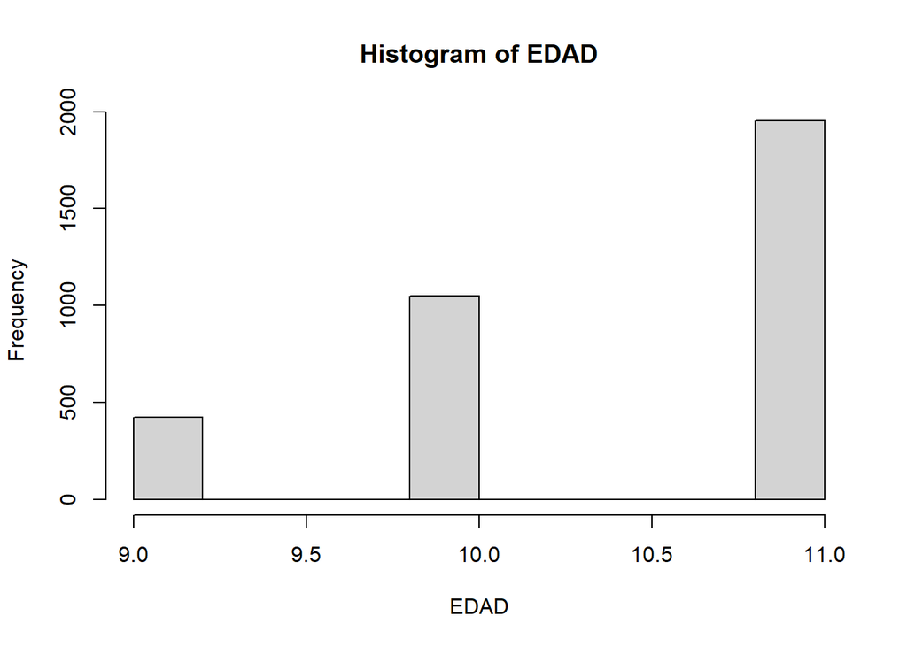

```r
summary(EDAD)
```

```
##    Min. 1st Qu.  Median    Mean 3rd Qu.    Max.
##    9.00   10.00   11.00   10.45   11.00   11.00
```

- En primer lugar, lo evidente que resalta del gráfico es que el rango de edad de las personas encuestadas se centra en 9 a 11 años. Según el gráfico, la mayoría de infantes encuestados tienen 11 años de edad. Mientras que, menos de 500 encuestados cuentan con 9 años de edad. Asimismo, la distribución de datos tiende hacia la izquierda, lo cual indica que la mayor cantidad de encuestados se concentran en las edades de 10 a 11 años. Cabe destacar que, en promedio la edad de los niños y niñas encuestados es de 10.45 años.

**Gráfico de pie sobre la distribución de datos según el sexo de los encuestados en ENARES 2019**

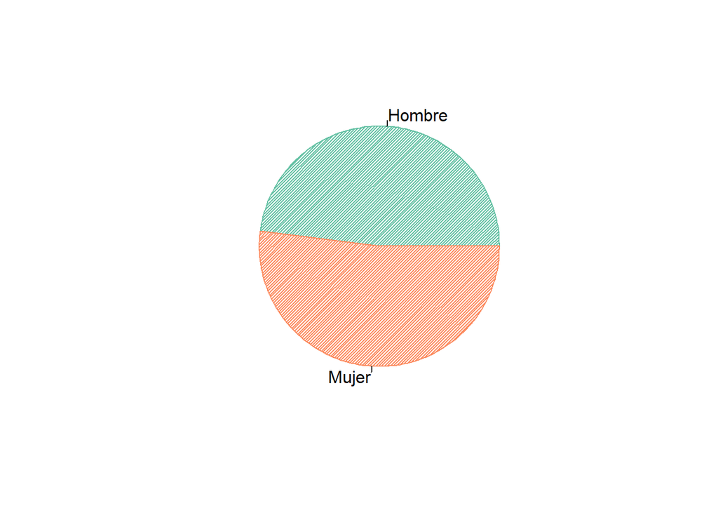

- De manera gráfico, se puede deducir que el número de niñas encuestadas es superior al número de niños encuestados.

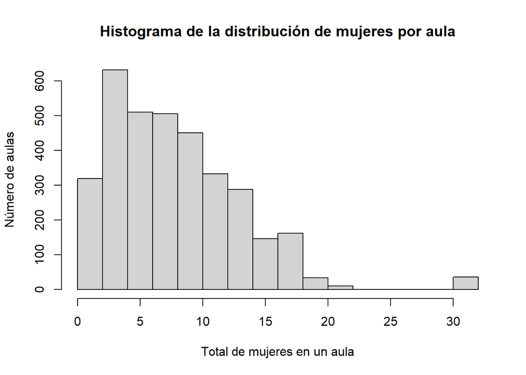

```r
hist(TOTAL_M, xlab="Total de mujeres en un aula", ylab="Número de aulas", main="Histograma de la distribución de mujeres por aula")
```

```r
summary(TOTAL_M)
```

```
##    Min. 1st Qu.  Median    Mean 3rd Qu.    Max.
##   0.000   4.000   8.000   8.322  11.000  31.000
```

- En primer lugar, el rango de valores que representan a las mujeres que estudian en un aula deriva desde 0 a 30. Asimismo, se observa que la distribución de datos tiende hacia la derecha, lo cual indica que hay mayor cantidad de puntuaciones bajas. Es decir, el número de mujeres que estudian en un aula de una institución educativa es relativamente bajo. Asimismo, se observa que en promedio 8.322 mujeres estudian en un aula.

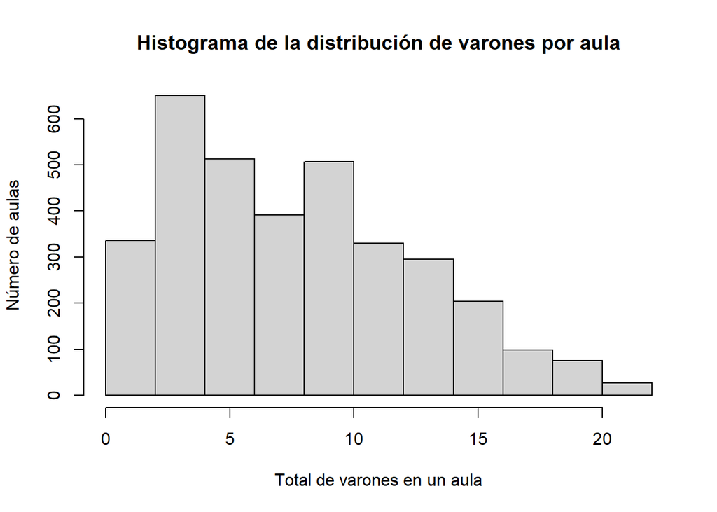

```r
hist(TOTAL_V, xlab="Total de varones en un aula", ylab="Número de aulas", main="Histograma de la distribución de varones por aula")
```

```r
summary(TOTAL_V)
```

```
##    Min. 1st Qu.  Median    Mean 3rd Qu.    Max.
##   0.000   4.000   7.000   8.159  12.000  22.000
```

**Gráfico de pie sobre la distribución de datos según el tipo de vivienda en el que residen los encuestados**

```r
str(Vivienda)
```

```
##  Factor w/ 2 levels "Albergue","Casa": 2 2 2 2 2 2 2 2 2 2 ...
```

```r
TABLA2=table(Vivienda)
color<-brewer.pal(length(TABLA2), "Set2")
```

[figure not shown]

```r
pie(TABLA2, col=color, density=50, angle=45)
```

```r
table(Vivienda)
```

```
## Vivienda
## Albergue     Casa
##        2     3424
```

- Según lo observado, la tajada del pastel evidentemente más grande corresponde a la categoría “casa”, lo cual indica que la gran mayoría de niños y niñas encuestados residen en una casa. Mientras que una ínfima minoría reside en un albergue.

**Gráfico de barras de la distribución de institución educativas adscritas al DRE**

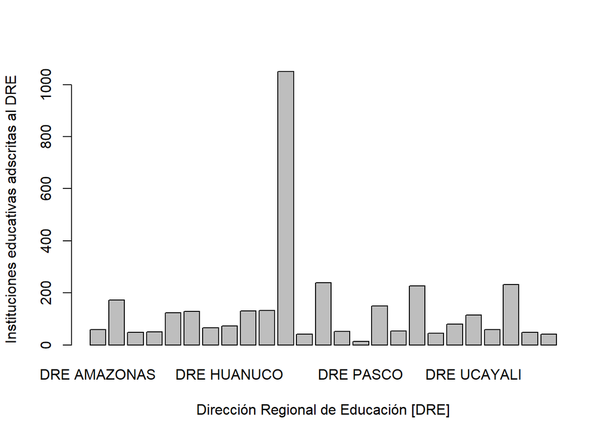

```r
TABLA3
```

```
## DIREED
##        DRE AMAZONAS          DRE ANCASH        DRE APURIMAC        DRE AYACUCHO
##                  58                 172                  48                  50
##       DRE CAJAMARCA           DRE CUSCO    DRE HUANCAVELICA         DRE HUANUCO
##                 124                 128                  66                  72
##             DRE ICA           DRE JUNIN            DRE LIMA DRE LIMA PROVINCIAS
##                 130                 132                1050                  42
##          DRE LORETO   DRE MADRE DE DIOS           DRE PASCO           DRE PIURA
##                 238                  52                  14                 150
##            DRE PUNO      DRE SAN MARTIN           DRE TACNA          DRE TUMBES
##                  54                 227                  44                  80
##         DRE UCAYALI        GRE AREQUIPA     GRE LA LIBERTAD      GRE LAMBAYEQUE
##                 114                  58                 232                  49
##        GRE MOQUEGUA
##                  42
```

- Tal como se observa en el gráfico, la DRE de Lima cuenta con el mayor número de instituciones educativas adscritas, el cual 1050; mientras que la DRE de Pasco cuenta con el menor número que es 14.

**Gráfico de barras de la distribución de institución educativas según su tipo**

```
## INED
##   MIXTO MUJERES
##    3354      72
```

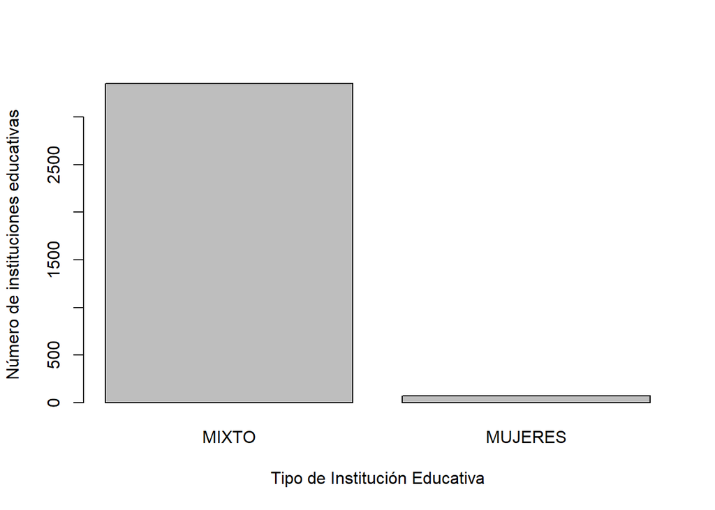

```r
table(INED)
```

```
## INED
##   MIXTO MUJERES
##    3354      72
```

- Tal como se puede apreciar en el gráfico, las institución educativas mixtas, es decir, donde estudian de manera conjunta niños y niñas es ampliamente superior en número a las instituciones educativa solo para mujeres. Asimismo, se evidencia que la encuesta realizada se centra en instituciones educativas donde los infantes pueden mayoritariamente compartir de manera libre con sus pares de distinto género. En tal sentido, al estudiar los factores que permiten explicar la variabilidad de los índices de violencia tanto psicológica como física será interesante analizar la variable sexo y tipo de institución educativa respecto a la variable dependiente.

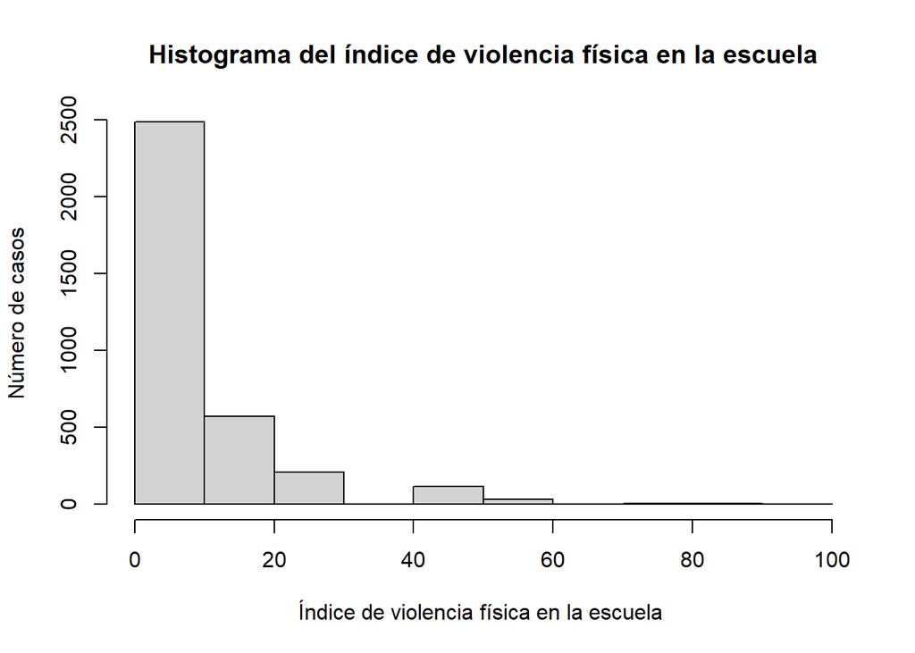

```r
summary(V_Física_Esc)
```

```
##    Min. 1st Qu.  Median    Mean 3rd Qu.    Max.
##   0.000   0.000   0.000   6.467  14.286 100.000
```

- Según el gráfico, el rango de valores del índice de violencia física en la escuela va desde 0 a 100. Asimismo, se observa que la distribución de datos tiende hacia la derecha, lo cual evidencia que la concentración de valores radica en los números relativamente bajos. Cabe destacar que, el puntaje medio del índice de violencia física en la escuela es 6.467 puntos, el cual es un puntaje bastante bajo. Ello nos permite indicar de manera preliminar que, en la escuela los niveles de violencia física entre pares es bastante bajo y no sería de gran preocupación y riesgo. Por ende, la escuela sería un lugar relativamente seguro de violencia física para los infantes.

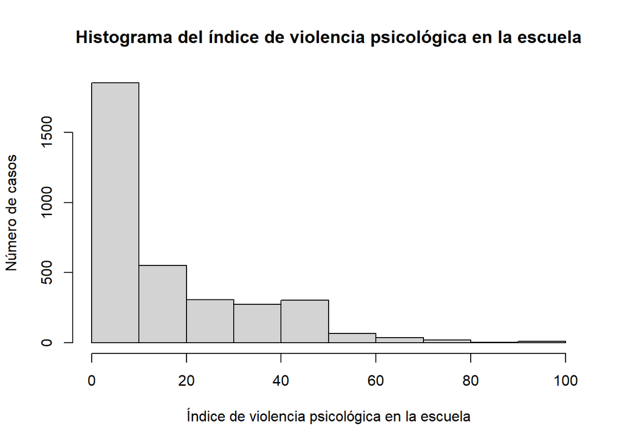

```r
summary(V_Psicológica_Esc)
```

```
##    Min. 1st Qu.  Median    Mean 3rd Qu.    Max.
##   0.000   0.000   8.333  15.747  25.000 100.000
```

- Según el histograma, se observa que el rango de valores del índice de violencia psicológica en la escuela va de 0 a 100. Igualmente, se aprecia que la distribución de valores tiende hacia la derecha, lo cual indica que la concentración de datos se enfoca en los valores más bajos. Cabe destacar que, el puntaje medio del índice de violencia psicológica en la escuela es de 15.747 puntos, el cual es un puntuaje relativamente bajo. Ello nos permite afirmar, de manera preliminar que, la escuela se proyectaría como un espacio seguro y medianamente libre de violencia psicológica para los infantes de 9 a 11 años.

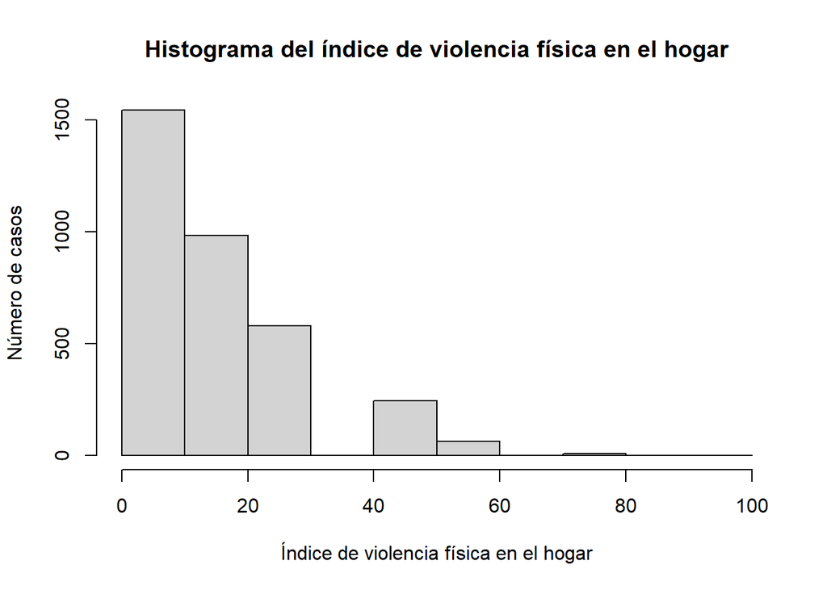

```r
summary(V_Física_Fam)
```

```
##    Min. 1st Qu.  Median    Mean 3rd Qu.    Max.    NA's
##    0.00    0.00   14.29   13.28   28.57  100.00       2
```

- Tal como se observa en el histograma, el rango de valores del índice de violencia física en el entorno familiar oscila del 0 al 100. Adicionalmente, se aprecia que la distribución de datos tiende hacia la derecha, lo cual indica que los valores se concentran en los datos relativamente más bajos. Cabe destacar que, en promedio el puntaje medio del índice de violencia física en el hogar es de 13.28 puntos. Dicho puntaje es relativamente bajo, lo cual permite afirmar de manera preliminar que el entorno familiar es relativamente seguro y libre de violencia física para los infantes.

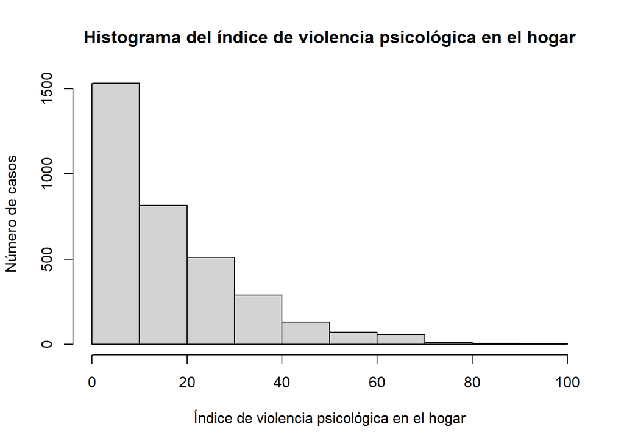

```r
summary(V_Psicológica_Fam)
```

```
##    Min. 1st Qu.  Median    Mean 3rd Qu.    Max.
##    0.00    0.00   11.11   13.26   22.22  100.00
```

- Según lo observado en el histograma, el rango de valores del índice de violencia psicológica oscila entre 0 al 100. Asimismo, se aprecia que la distribución de datos tiende hacia la derecha, lo cual indica que los valores se concentran en los puntajes más bajos. Cabe señalar que, el puntaje medio del índice de violencia psicológica en el entorno familiar es de 13.26 puntos. Dicho puntaje es relativamente bajo, lo cual permite mencionar de manera preliminar que el hogar de los niños y niñas de 9 a 11 años es un espacio medianamente seguro y libre de violencia psicológico para los infantes.

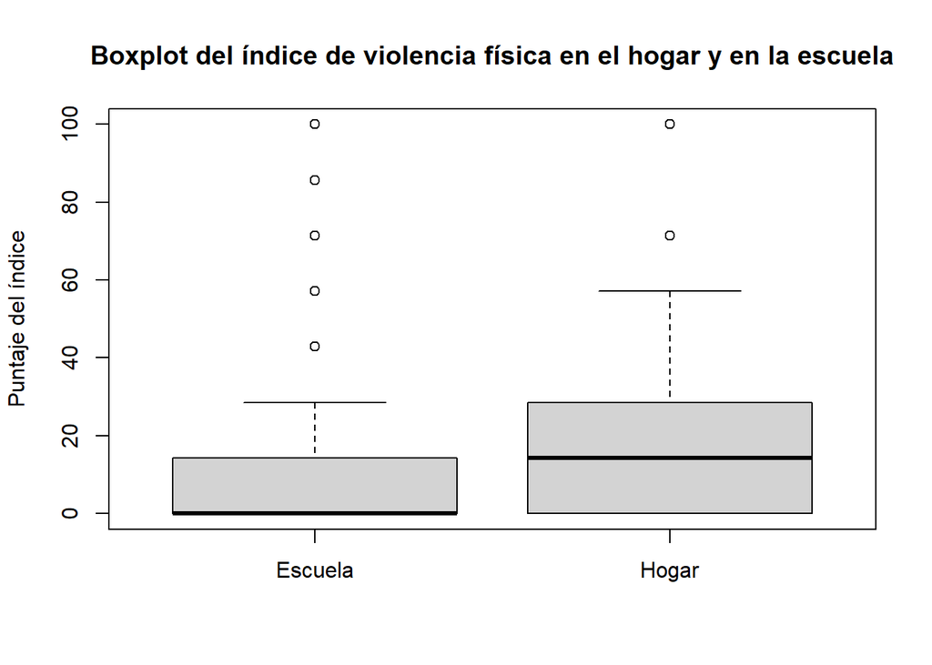

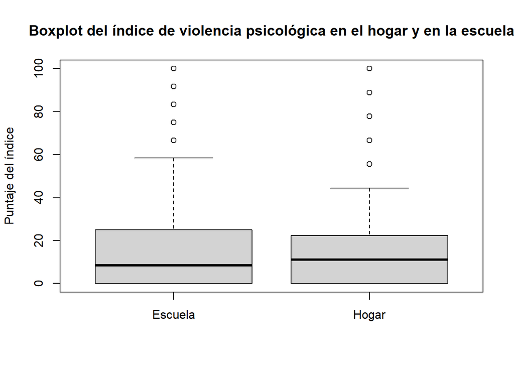

```
##
##  Descriptive statistics by group
## group: Hombre
##    vars    n  mean    sd median trimmed   mad min max range skew kurtosis   se
## X1    1 1642 14.19 15.67  14.29   11.79 21.18   0 100   100 1.06     0.85 0.39
## ------------------------------------------------------------
## group: Mujer
##    vars    n  mean    sd median trimmed   mad min   max range skew kurtosis
## X1    1 1782 12.45 14.53  14.29   10.23 21.18   0 71.43 71.43 1.02     0.32
##      se
## X1 0.34
```

- En el caso de las niñas de 9 a 11 años encuestadas, el puntaje medio que se les asignó en cuanto al índice de violencia físcia en el entorno familiar es de 12.45 puntos. Mientras que el puntaje medio del mismo índice para los niños de 9 a 11 años es de 14.19 puntos. A partir de ello, se puede deducir de manera preliminar que, los niños de 9 a 11 años son más propensos a recibir algún tipo de acción referente a la violencia física en el hogar en comparación de sus pares femeninos.

```
##
##  Descriptive statistics by group
## group: Hombre
##    vars    n mean    sd median trimmed mad min   max range skew kurtosis   se
## X1    1 1644 7.34 13.24      0    4.28   0   0 85.71 85.71 2.11      4.7 0.33
## ------------------------------------------------------------
## group: Mujer
##    vars    n mean    sd median trimmed mad min max range skew kurtosis   se
## X1    1 1782 5.66 12.41      0    2.55   0   0 100   100 3.05    12.16 0.29
```

- El puntaje medio de las niñas encuestadas de 9 a 11 años respecto al índice de violencia física en la escuela es de 5.66 puntos. Mientras que el puntaje medio del mismo índice en el caso de los niños de 9 a 11 años es de 7.34 puntos. En tal sentido, se puede mencionar, de manera preliminar que, los niños de 9 a 11 años son más propensos a recibir algún tipo de castigo físico en la escuela en comparación a sus pares femeninos.

```
##
##  Descriptive statistics by group
## group: Hombre
##    vars    n  mean    sd median trimmed   mad min max range skew kurtosis   se
## X1    1 1644 13.12 17.22  11.11    9.79 16.47   0 100   100 1.71     3.16 0.42
## ------------------------------------------------------------
## group: Mujer
##    vars    n  mean    sd median trimmed   mad min   max range skew kurtosis
## X1    1 1782 13.39 16.26  11.11    10.6 16.47   0 88.89 88.89 1.43     1.99
##      se
## X1 0.39
```

- El puntaje medio de las niñas de 9 a 11 años encuestadas respecto al índice de violencia psicológica en el hogar es de 13.39 puntos. Mientras que el puntaje medio del mismo índice de los niños de 9 a 11 años es de 13.12 puntos. A raíz de ello, se puede deducir preliminarmente que, las niñas de 9 a 11 años recibirían en promedio mayor cantidad de acciones relacionadas a la violencia psicológica en el hogar en comparación a sus pares masculinos.

```
##
##  Descriptive statistics by group
## group: Hombre
##    vars    n  mean   sd median trimmed   mad min   max range skew kurtosis   se
## X1    1 1644 14.54 16.7   8.33   11.71 12.35   0 91.67 91.67  1.3     1.39 0.41
## ------------------------------------------------------------
## group: Mujer
##    vars    n  mean    sd median trimmed   mad min max range skew kurtosis   se
## X1    1 1782 16.86 18.83   8.33   13.87 12.35   0 100   100 1.25     1.29 0.45
```

- El puntaje medio de las niñas de 9 a 11 años respecto al índice de violencia psicológica en la escuela es de 16.86 puntos. Mientras que el puntaje medio del mismo índice de los niños de 9 a 11 años es de 14.54 puntos. En tal sentido, se puede afirmar preliminarmente que, las niñas de 9 a 11 años recibirían en promedio mayor cantidad de acciones relacionadas a la violencia psicológica en la escuela en comparación a sus pares masculinos.

```
##
##  Descriptive statistics by group
## group: 9
##    vars   n mean    sd median trimmed mad min   max range skew kurtosis   se
## X1    1 425 7.83 14.67      0    4.32   0   0 85.71 85.71 2.37     6.17 0.71
## ------------------------------------------------------------
## group: 10
##    vars    n mean    sd median trimmed mad min   max range skew kurtosis   se
## X1    1 1049 7.22 13.43      0    4.01   0   0 71.43 71.43 2.11     4.21 0.41
## ------------------------------------------------------------
## group: 11
##    vars    n mean    sd median trimmed mad min max range skew kurtosis   se
## X1    1 1952 5.77 12.02      0    2.79   0   0 100   100 2.89    11.51 0.27
```

```
##
##  Descriptive statistics by group
## group: 9
##    vars   n mean    sd median trimmed   mad min   max range skew kurtosis   se
## X1    1 425 18.1 18.81  16.67   15.44 24.71   0 83.33 83.33 1.01     0.29 0.91
## ------------------------------------------------------------
## group: 10
##    vars    n  mean    sd median trimmed   mad min   max range skew kurtosis
## X1    1 1049 16.36 18.47   8.33   13.35 12.35   0 91.67 91.67 1.24     0.98
##      se
## X1 0.57
## ------------------------------------------------------------
## group: 11
##    vars    n mean    sd median trimmed   mad min max range skew kurtosis   se
## X1    1 1952 14.9 17.28   8.33   12.01 12.35   0 100   100 1.39     2.05 0.39
```

```
##
##  Descriptive statistics by group
## group: 9
##    vars   n  mean    sd median trimmed   mad min max range skew kurtosis   se
## X1    1 425 14.49 16.94  14.29   11.86 21.18   0 100   100 1.18     1.38 0.82
## ------------------------------------------------------------
## group: 10
##    vars    n  mean    sd median trimmed   mad min   max range skew kurtosis
## X1    1 1047 14.14 15.98  14.29    11.7 21.18   0 71.43 71.43 1.01     0.28
##      se
## X1 0.49
## ------------------------------------------------------------
## group: 11
##    vars    n  mean    sd median trimmed   mad min   max range skew kurtosis
## X1    1 1952 12.57 14.15  14.29   10.55 21.18   0 71.43 71.43 0.98     0.36
##      se
## X1 0.32
```

```
##
##  Descriptive statistics by group
## group: 9
##    vars   n  mean    sd median trimmed   mad min   max range skew kurtosis   se
## X1    1 425 12.99 15.93  11.11   10.26 16.47   0 77.78 77.78 1.34     1.51 0.77
## ------------------------------------------------------------
## group: 10
##    vars    n mean    sd median trimmed   mad min max range skew kurtosis   se
## X1    1 1049 15.2 18.84  11.11   11.73 16.47   0 100   100  1.5     2.16 0.58
## ------------------------------------------------------------
## group: 11
##    vars    n  mean    sd median trimmed   mad min   max range skew kurtosis
## X1    1 1952 12.27 15.57  11.11    9.48 16.47   0 88.89 88.89 1.59     2.76
##      se
## X1 0.35
```

**Variables relacionadas a Constitución Familiar**

- La ausencia de uno de los padres es un factor de riesgo. Provenir de un hogar que en la primera visita era monoparental se asocia con un incremento en la probabilidad de convertirse en víctima de violencia física o psicológica (Sánchez e Hidalgo, 2019).

```r
#### variable: Vive con su padre
str(enares_2019$C3P115_2)
```

```
##  num [1:3426] 1 1 1 1 1 1 1 0 0 1 ...
##  - attr(*, "label")= chr "115.2 EN TU CASA, ¿CON QUIENES VIVES? PADRE"
##  - attr(*, "format.spss")= chr "F11.0"
##  - attr(*, "display_width")= int 0
##  - attr(*, "labels")= Named num 1
##   ..- attr(*, "names")= chr "Padre"
```

```r
table(enares_2019$C3P115_2)
```

```
##
##    0    1
##  888 2536
```

```r
enares_2019$C3P115_2 <- car::recode(enares_2019$C3P115_2, "1='Sí'; 0='No'")
table(enares_2019$C3P115_2)
```

```
##
##   No   Sí
##  888 2536
```

```r
#### variable: Vive con su madre
str(enares_2019$C3P115_1)
```

```
##  num [1:3426] 1 1 1 1 1 1 1 0 0 1 ...
##  - attr(*, "label")= chr "115.1 EN TU CASA, ¿CON QUIENES VIVES? MADRE"
##  - attr(*, "format.spss")= chr "F11.0"
##  - attr(*, "display_width")= int 0
##  - attr(*, "labels")= Named num 1
##   ..- attr(*, "names")= chr "Madre"
```

```r
table(enares_2019$C3P115_1)
```

```
##
##    0    1
##  195 3229
```

```r
enares_2019$C3P115_1 <- car::recode(enares_2019$C3P115_1, "1='Sí'; 0='No'")
table(enares_2019$C3P115_1)
```

```
##
##   No   Sí
##  195 3229
```

```r
#### Filtro basado en que el infante vive SOLO con su padre, pero no con su madre
filter(enares_2019, C3P115_2=="Sí", C3P115_1=="No")
```

[output not shown]

[output cut: 4629 more lines]

```r
#### Filtro basada en que el infante vive SOLO con su madre
filter(enares_2019, C3P115_2=="No", C3P115_1=="Sí")
```

[output not shown]

[output cut: 13791 more lines]

```r
#### Filtro basado en que el infante vive con ambos padres
filter(enares_2019, C3P115_2=="Sí", C3P115_1=="Sí")
```

[output not shown]

[output cut: 13791 more lines]

> **Posibles pruebas estadísticas a utilizar para responder a la pregunta de investigación planteada**

#### **Modelo de regresión Poisson**

- Se seleccionó al modelo de regresión de Poisson debido a que las variables dependientes de los siguientes 4 modelos son del tipo numérico discreta, mientras que sus variables explicativas son tanto categóricas como numéricas.

###### Modelo 1

- **Variable dependiente**: índice de violencia física en el hogar (Variable númerica discreta)

```r
class(V_Física_Fam)
```

```
## [1] "numeric"
```

- **Posibles Variables independientes**:
  - Constitución familiar (Vive solo con el padre, vive solo con la madre, vive con ambos padres): C3P115_2 y C3P115_1
  - Lugar de residencia: DIREED
  - EDAD: EDAD
  - Total de varones: TOTAL_V
  - Total de mujeres: TOTAL_M
  - SEXO: SEXO
  - Condición socioeconómica (“Por tener plata”, “por no tener plata”): Tiene_Plata y No_Tiene_Plata
  - Tipo de vivienda: VIVIENDA

###### Modelo 2

- **Variable dependiente**: índice de violencia psicológica en el hogar (Variable númerica discreta)

```r
class(V_Psicológica_Fam)
```

```
## [1] "numeric"
```

- **Posibles Variables independientes**:
  - Constitución familiar (Vive solo con el padre, vive solo con la madre, vive con ambos padres): C3P115_2 y C3P115_1
  - Lugar de residencia: DIREED
  - EDAD: EDAD
  - Total de varones: TOTAL_V
  - Total de mujeres: TOTAL_M
  - SEXO: SEXO
  - Condición socioeconómica (“Por tener plata”, “por no tener plata”): Tiene_Plata y No_Tiene_Plata
  - Rendimient Académico (“Por tener buenas notas”, “Por tener malas notas”): Buenas_Notas y Malas_Notas
  - Tipo de vivienda: VIVIENDA

###### Modelo 3

- **Variable dependiente**: índice de violencia física en la escuela (Variable númerica discreta)

```r
class(V_Física_Esc)
```

```
## [1] "numeric"
```

- **Posibles Variables independientes**:
  - Lugar de residencia: DIREED
  - SEXO: SEXO
  - Total de varones: TOTAL_V
  - Total de mujeres: TOTAL_M
  - Condición socioeconómica (“Por tener plata”, “por no tener plata”): Tiene_Plata y No_Tiene_Plata
  - Rendimient Académico (“Por tener buenas notas”, “Por tener malas notas”): Buenas_Notas y Malas_Notas
  - Tipo de institución educativa: INED

###### Modelo 4

- **Variable dependiente**: índice de violencia psicológica en la escuela (Variable númerica discreta)

```r
class(V_Psicológica_Esc)
```

```
## [1] "numeric"
```

- **Posibles Variables independientes**:
  - Lugar de residencia: DIREED
  - Total de varones: TOTAL_V
  - Total de mujeres: TOTAL_M
  - SEXO: SEXO
  - Condición socioeconómica (“Por tener plata”, “por no tener plata”): Tiene_Plata y No_Tiene_Plata
  - Rendimient Académico (“Por tener buenas notas”, “Por tener malas notas”): Buenas_Notas y Malas_Notas
  - Tipo de institución educativa: INED

#### **Modelo de regresión logística ordinal**

- Se seleccionó el modelo de regresión logística ordinal debido a que la variable dependiente de los siguientes cuatro modelos es del tipo categórica ordinal, mientras que sus variables explicativas son tanto categóricas como numéricas

###### Modelo 1

- **Variable dependiente**: Frecuencia en que ocurren agresiones físicas en el hogar (Variable categórica ordinal): C3P208

```r
class(enares_2019$C3P208)
```

```
## [1] "ordered" "factor"
```

- **Posibles Variables independientes**:
  - Constitución familiar (Vive solo con el padre, vive solo con la madre, vive con ambos padres): C3P115_2 y C3P115_1
  - Lugar de residencia: DIREED
  - Total de varones: TOTAL_V
  - Total de mujeres: TOTAL_M
  - Tipo de Vivienda: VIVIENDA
  - EDAD: EDAD
  - SEXO: SEXO
  - Condición socioeconómica (“Por tener plata”, “por no tener plata”): Tiene_Plata y No_Tiene_Plata

###### Modelo 2

- **Variable dependiente**: Frecuencia en que ocurren agresiones psicológicas en el hogar (Variable categórica ordinal): C3P204

```r
class(enares_2019$C3P204)
```

```
## [1] "ordered" "factor"
```

- **Posibles Variables independientes**:
  - Constitución familiar (Vive solo con el padre, vive solo con la madre, vive con ambos padres): C3P115_2 y C3P115_1
  - Lugar de residencia: DIREED
  - Total de varones: TOTAL_V
  - Total de mujeres: TOTAL_M
  - EDAD: EDAD
  - SEXO: SEXO
  - Tipo de vivienda: VIVIENDA
  - Condición socioeconómica (“Por tener plata”, “por no tener plata”): Tiene_Plata y No_Tiene_Plata
  - Rendimient Académico (“Por tener buenas notas”, “Por tener malas notas”): Buenas_Notas y Malas_Notas

###### Modelo 3

- **Variable dependiente**: Frecuencia en que ocurren agresiones física en la escuela (Variable categórica ordinal): C3P230

```r
class(enares_2019$C3P230)
```

```
## [1] "ordered" "factor"
```

- **Posibles Variables independientes**:
  - Lugar de residencia: DIREED
  - Total de varones: TOTAL_V
  - Total de mujeres: TOTAL_M
  - SEXO: SEXO
  - Condición socioeconómica (“Por tener plata”, “por no tener plata”): Tiene_Plata y No_Tiene_Plata
  - Rendimient Académico (“Por tener buenas notas”, “Por tener malas notas”): Buenas_Notas y Malas_Notas
  - Tipo de colegio: INED

###### Modelo 4

- **Variable dependiente**: Frecuencia en que ocurren agresiones psicológicas en la escuela (Variable categórica ordinal): C3P226

```r
class(enares_2019$C3P226)
```

```
## [1] "ordered" "factor"
```

- **Posibles Variables independientes**:
  - Lugar de residencia: DIREED
  - Total de varones: TOTAL_V
  - Total de mujeres: TOTAL_M
  - SEXO: SEXO
  - Condición socioeconómica (“Por tener plata”, “por no tener plata”): Tiene_Plata y No_Tiene_Plata
  - Rendimient Académico (“Por tener buenas notas”, “Por tener malas notas”): Buenas_Notas y Malas_Notas
  - Tipo de colegio: INED

> **Bibliografía**

Benavides, M. y León, J. (2013). Una mirada a la violencia física contra los niños y niñas en los hogares peruanos: magnitudes, factores asociados y transmisión de la violencia de madres a hijos e hijas. (Documento de Trabajo, 71). GRADE Group for the Analysis of Development. https://nbn-resolving.org/urn:nbn:de:0168-ssoar-51563-4 Defensoría del Pueblo (s.f.). Niñez y adolescencia. https://www.defensoria.gob.pe/grupos_de_proteccion/ninez-adolescencia-y-adultos-mayores/ D.S. N°004-2018-MINEDU. Que aprueba los Lineamientos para la Gestión de la Convivencia Escolar, la Prevención y la Atención de la Violencia Contra Niñas, Niños y Adolescentes. Ministerio de Educación (2018). https://www.gob.pe/institucion/minedu/normas-legales/273491-004-2018 D.S. N° 009-2019-M. Que aprueba los lineamientos para incorporar el enfoque intercultural en la prevención, atención y protección frente a la violencia sexual contra niños, niñas, adolescentes y mujeres indígenas u originarias. Ministerio de Cultura (2019). https://www.gob.pe/institucion/cultura/normas-legales/289561-ds-n-009-2019-mc D.S. N° 008-2021-MIMP. Mediante el cual se aprueba la Política Nacional Multisectorial para las Niñas, Niños y Adolescentes al 2030. Ministerio de la Mujer y Poblaciones Vulnerables. Diario Oficial el Peruano (2021). https://busquedas.elperuano.pe/normaslegales/decreto-supremo-que-aprueba-la-politica-nacional-multisector-decreto-supremo-no-008-2021-mimp-1966624-1/ Fondo de las Naciones Unidas para la Infancia (2019). El gran problema es que la violencia en el país es cotidiana y, aún peor, está normalizada, es decir, es considerada una práctica válida para corregir, controlar o mostrar poder sobre los niños, niñas y adolescentes. https://www.unicef.org/peru/sites/unicef.org.peru/files/2019-09/cifras-violencia-ninas-ninos-adolescentes-peru-2019.pdf García, M. (2018). Causas y prevención del bullying: programa de prevención [Tesis para obtener el título de Licenciado, Universitat de les Illes Balears]. http://hdl.handle.net/11201/152405 Gonzáles-Muriel, C. (1998). Factores de riesgo del maltrato y abandono infantil desde una perspectiva multicausal. Aula, 8, pp. 29-44. https://doi.org/10.14201/3417 Instituto de Estadística e Informática (2020). Encuesta Nacional sobre Relaciones Sociales 2019.http://iinei.inei.gob.pe/microdatos/ Ley Nº 26518. Para la creación del Sistema Nacional de Atención Integral al Niño y el Adolescente, de 24 de julio de 1995. Ley Nº 27337. Por la cual se aprueba el Nuevo Código de los Niños y Adolescentes. 21 de julio de 2000. Ley N° 30364. Por la cual se aprueba la Ley para prevenir, sancionar y erradicar la violencia contra las mujeres y los integrantes del grupo familiar. 6 de noviembre de 2015. D.O. N°1314999_1. Ley N°30403. Por la cual se prohíbe el uso del castigo físico y humillante contra los niños, niñas, y adolescentes en el hogar, la escuela, la comunidad, lugares de trabajo y otros relacionados. 29 de diciembre de 2015. D.O. N° 1328702_1. Ministerio de la Mujer y Poblaciones Vulnerables (s.f). Plan Nacional de Acción por la Infancia y la Adolescencia. https://www.mimp.gob.pe/webs/mimp/pnaia/index.php Ministerio de la Mujer y Poblaciones Vulnerables (2020). Programa Nacional para la Prevención y Erradicación de la Violencia contra las Mujeres e Integrantes del Grupo Familiar . Aurora. Boletín estadístico.  
Perú21 (28 de septiembre de 2021). Aumenta el número de casos de violencia contra niñas, niños y adolescentes a raíz de la pandemia. Perú 21. https://peru21.pe/lima/pandemia-violencia-maltrato-ninos-ninas-adolescentes-aumenta-el-numero-de-casos-de-violencia-contra-ninas-ninos-y-adolescentes-a-raiz-de-la-pandemia-noticia/ Observatorio Nacional de la Violencia Contra las Mujeres y los Integrantes del grupo familiar (21 de agosto del 2018). Los niños, niñas y adolescentes: población vulnerable al maltrato y al abuso. https://observatorioviolencia.pe/ninez-vulnerable-al-maltrato/ Olweus, D. (2014). Acoso escolar, “Bullying”, en las escuelas: hechos e intervenciones. University of Bergen. https://www.researchgate.net/publication/253157856_ACOSO_ESCOLARBULLYING_EN_LAS_ESCUELAS_HECHOS_E_INTERVENCIONES Oré, B. y Diez Canseco, F. (2011). Narrativas acerca del cuidado y la violencia hacia niños y niñas en el hogar: estudio en cuatro comunidades del Perú. GRADE Grupo de Análisis para el Desarrollo. Sánchez, A. e Hidalgo, A. (2019). Medición de la prevalencia de la violencia física y psicológica hacia niñas, niños y adolescentes, y sus factores asociados en el Perú: Evidencia de Niños del Milenio. (Avances de Investigación 38). GRADE Grupo de Análisis para el Desarrollo. http://repositorio.grade.org.pe/handle/GRADE/504